# Lake Mixing Eddie Module

# Eddie Module Lake Mixing

This is an adaption of the eddie module on lake mixing and is here primarily to do the graphing of the air temperature, wind speed and Schmidts stability

## Install libraries

Install libraries for use to examine data using tidyverse this only has to be done one time and a # can be put in front of the code to comment it out so it does not run in the future as now.

```r
# install.packages("tidyverse")
# install.packages("readxl")
# install.packages("janitor")
# install.packages("lubridate")
# install.packages("broom")
# install.packages("patchwork")
```

## Load libraries

Load the libraries each time you run a script or program

```r
library(tidyverse) # loads a lot of libraries in this one to add more functionality
library(readxl) # allows you to read in excel files
library(janitor) # cleans up column names and removes empty columns if wanted
library(lubridate) # allows easy conversion of varaibles to date format
library(broom) # cleans up output for easy presentation
library(scales) # works with the x and y scales on the plots
library(patchwork) # allows you to plot several graphs on one page
```

## Read file

Note since they are all in different sheets you can change  
sheet = “name of lake”  
to the name you are interested in to read in that lake

Read in Lake Annie and stores in the annie.df dataframe in the environment tab.  
Note this is slightly different than in the regular scipt  
the `../` has to be used as this file thinks the main working directory is  
where it is located so we have to jump up one level and then use /data

```r
annie.df <- read_excel("../data/lake_mixing_module_dataset.xlsx",
                         # identifies the file to read in
  sheet="Annie", # identifies the sheet to read in
  guess_max = 1000, # allows more rows to guess the type of data
  skip = 1) # skips the first row of data
```

## Schmidt Stability vs time

Plot Schmidt stability vs. time for your lake. What is the maximum Schmidt stability value and when does it occur? Answers are in the instructor’s version of the dataset spreadsheet.

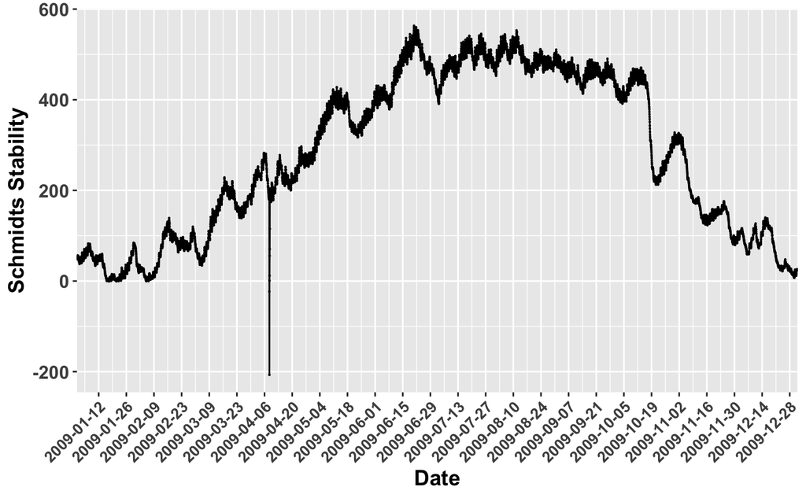

```r
stability.plot <- annie.df %>% # uses annie data and stores it in this plot name
  ggplot(aes(x = datetime, y = st)) + # x is the datetime and y is the stability
  geom_line() + # this adds in a line for the graph
  geom_point(size = 0.1) + # this adds in points - can add a # to get rid of it
  scale_x_datetime(date_breaks = "2 week",
                   # this adjusts the scale breaks - days, weeks months
              # limits = as_datetime(c('2017-06-01 00:00:00','2017-08-01 00:00:00')),
              # can adjust the limits in the range you want if you want to look sub times
              labels=date_format("%Y-%m-%d"), expand=c(0,0)) +
  # this makes the date format on the x axis
  labs(
    x= "Date", # labels the x axis
    y = "Schmidts Stability" # labels the y axis
  ) +
theme(
    # Modifies the appearane of the axes titles
    axis.title.x=element_text(size=14, face="bold"),
    axis.title.y=element_text(size=14, face="bold"),
    axis.text.x = element_text(size=10, face="bold", angle=45, hjust=1),
    axis.text.y = element_text(size=12, face="bold"))
stability.plot # jsut calls the plot
```

Plot the air temperature data and wind speed data vs. time for your lake to explore whether any of the changes in Schmidt stability from day to day are related to weather.

## Air temperature

Since there is so much data and it is hard to see the patters we have presented the daily mean of the data. If you would like to see all of the data you can comment out the chunk indicated below. This can all be done in one set of commands which is nice.

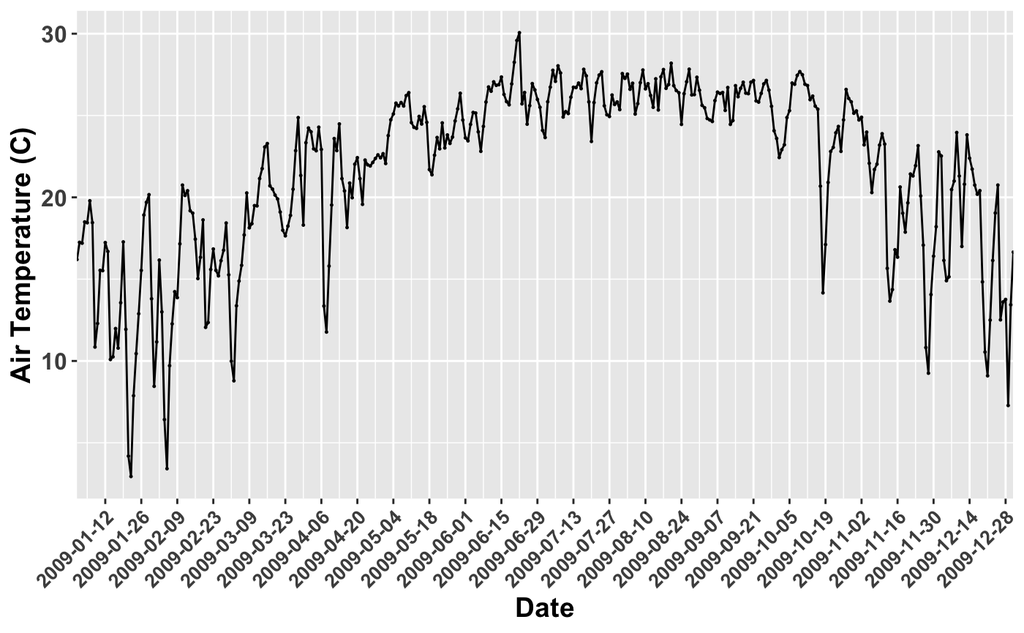

```r
airtemp.plot <- annie.df %>% # stores graph from data in this plot name
  # this section can be commented out to show all the data to the next indicator
  select(datetime, airt) %>% # this only retains these two columns of data
  mutate(datetime = as.Date(datetime)) %>% # converts datetime to date
  group_by(datetime) %>% # groups by day to get average by day
  summarize(airt = mean(airt, na.rm=TRUE)) %>% # takes the average of the variable by day
                              # na.rm - TRUE gets rid of any missing values
  # this is the end of of the comment senction to remove to see all data
  ggplot(aes(x = datetime, y = airt)) + # plot of datetime and air temperature
  geom_line() + # adds a line to the graph
  geom_point(size = 0.2) + # adds symbols to the graph but makes them small
  scale_x_date(date_breaks = "2 week", # 2 week breaks but can be months as well
  # need to be scale_x_datetime if you want all the data
              # limits = as_datetime(c('2017-06-01 00:00:00','2017-08-01 00:00:00')),
              labels=date_format("%Y-%m-%d"),  # sets the way the axis is labeled
              expand=c(0,0)) + # removes the extra space ggplot adds
  labs(
    x= "Date",  # label for x axis
    y = "Air Temperature (C)" # label for y axis
    # title = "Air Temperature (C)"
  ) +
theme(
    # Axes appearance
    axis.title.x=element_text(size=14, face="bold"),
    axis.title.y=element_text(size=14, face="bold"),
    axis.text.x = element_text(size=10, face="bold", angle=45, hjust=1),
    axis.text.y = element_text(size=12, face="bold"))
airtemp.plot
```

## Wind speed plot

Again this takes the daily average of wind speed to show the data a bit cleaner

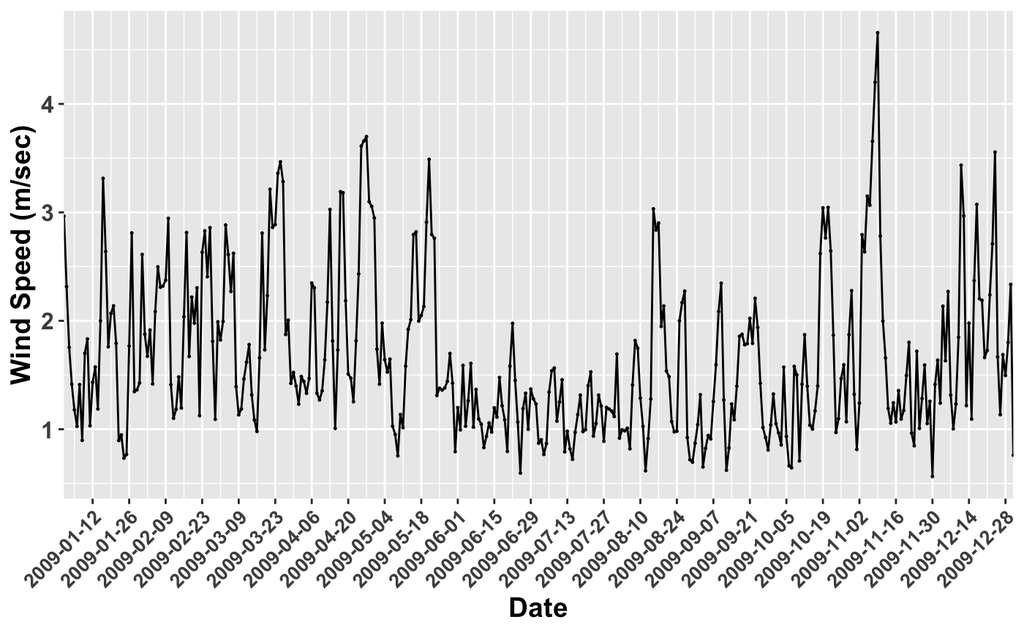

```r
windsp.plot <- annie.df %>% # stores graph from data in this plot name
  # this section can be commented out to show all the data to the next indicator
  select(datetime, windsp) %>% # this only retains these two columns of data
  mutate(datetime = as.Date(datetime)) %>% # converts datetime to date
  group_by(datetime) %>% # groups by day to get average by day
  summarize(windsp = mean(windsp, na.rm=TRUE)) %>% # takes the average of the variable by day
  # this is the end of of the comment senction to remove to see all data
  ggplot(aes(x = datetime, y = windsp)) +
  geom_line() +
  geom_point(size=0.2) +
  scale_x_date(date_breaks = "2 week", # need to be scale_x_datetime if you want all the data
              # limits = as_datetime(c('2017-06-01 00:00:00','2017-08-01 00:00:00')),
              labels=date_format("%Y-%m-%d"), expand=c(0,0)) +
  labs(
    x= "Date",
    y = "Wind Speed (m/sec)"
    # title = "Mean Wind Speed"
  ) +
theme(
    # LABLES APPEARANCE
    axis.title.x=element_text(size=14, face="bold"),
    axis.title.y=element_text(size=14, face="bold"),
    axis.text.x = element_text(size=10, face="bold", angle=45, hjust=1),
    axis.text.y = element_text(size=12, face="bold"))
windsp.plot
```

## Combine Plots

The plots can be combined into one to see all of the data at once lined up on the same scale. This allows you to see temperature and wind at the same time

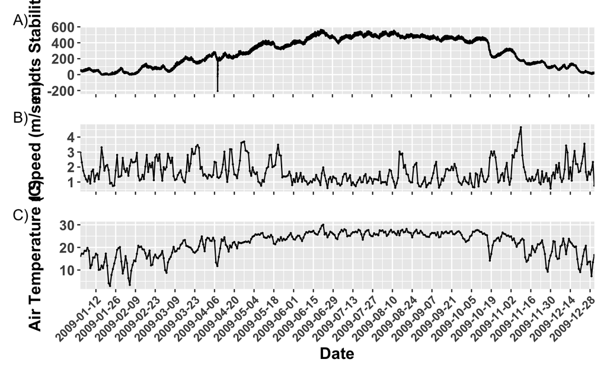

```r
stability.plot +  theme(axis.title.x=element_blank(), axis.text.x=element_blank(),
                    legend.position = "none") +
  windsp.plot + theme(axis.title.x=element_blank(), axis.text.x=element_blank(),
                   legend.position = "none") +
  airtemp.plot +
  plot_layout(ncol = 1)+
  plot_annotation(tag_levels = "A",
                  tag_suffix = ")")
```